# Linear Regression Analysis

PBIO 3150/5150

2016-04-12

Linear regression is useful for describing and predicting how a set of *independent variables* explain variation in (and predict) the *dependent variable*. The dependent variable can be continuous or categorical, and so also the independent variables. Since the goal is to estimate the true linear relationship between these variables by way of the sample we draw a distinction between the **population regression function (PRF)** and the **sample regression function (SRF)**:

$$\text{PRF: } y = \alpha + \beta(x) + \epsilon$$

$$\text{SRF: } \hat{y} = \hat{a} + \hat{b}(x) + e$$

A couple of things to bear in mind:

- $\epsilon$ and $e$ are the random errors present in every measurement of $y$ in the population and in the sample, respectively. These errors are random in that they cannot be predicted by any independent variable
- The relationships are assumed to be linear. Linearity here means that $b$ does not appear with a power greater than $1$. Thus models such as
  - $y = a + b(x^2) + e$,
  - $y = a + b(\dfrac{1}{x}) + e$, and
  - $y = a + b_1(x) + b_2(x^2) + e$,
  - etc. are all linear.

However, models such as $y = a + b^{1/2}(x) + e$ are not linear.

# Lions’ Noses

Does a lion’s age have any thing to do with what proportion of its nose is black? Let us load the data and run a simple regression with the lions’ ages as the dependent variable $(y)$ and the proportion of the nose that is black as the independent variable $(x)$. We’ll begin with a simple scatterplot of course to see if the two are correlated.

```r
lions = read.csv(url("http://whitlockschluter.zoology.ubc.ca/wp-content/data/chapter17/chap17e1LionNoses.csv"))
summary(lions)
```

```
##  proportionBlack    ageInYears
##  Min.   :0.1000   Min.   : 1.100
##  1st Qu.:0.1650   1st Qu.: 2.175
##  Median :0.2650   Median : 3.500
##  Mean   :0.3222   Mean   : 4.309
##  3rd Qu.:0.4325   3rd Qu.: 5.850
##  Max.   :0.7900   Max.   :13.100
```

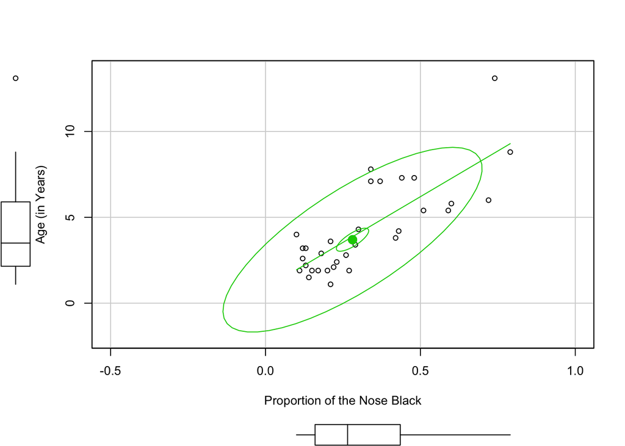

```r
library(car)
scatterplot(ageInYears ~ proportionBlack, data = lions, ellipse = TRUE, levels = c(0.05, 0.95), reg.line = lm, smoother = FALSE, xlab = "Proportion of the Nose Black", ylab = "Age (in Years)", xlim = c(-0.5, 1), ylim = c(-2, 13.5))
```

Fitting the regression model:

```r
lm.L = lm(ageInYears ~ proportionBlack, data = lions)
summary(lm.L)
```

```
##
## Call:
## lm(formula = ageInYears ~ proportionBlack, data = lions)
##
## Residuals:
##     Min      1Q  Median      3Q     Max
## -2.5449 -1.1117 -0.5285  0.9635  4.3421
##
## Coefficients:
##                 Estimate Std. Error t value Pr(>|t|)
## (Intercept)       0.8790     0.5688   1.545    0.133
## proportionBlack  10.6471     1.5095   7.053 7.68e-08 ***
## ---
## Signif. codes:  0 '***' 0.001 '**' 0.01 '*' 0.05 '.' 0.1 ' ' 1
##
## Residual standard error: 1.669 on 30 degrees of freedom
## Multiple R-squared:  0.6238, Adjusted R-squared:  0.6113
## F-statistic: 49.75 on 1 and 30 DF,  p-value: 7.677e-08
```

Note that the p-value is practically zero so it appears that proportionBlack is related to a lion’s age. How do we interpret this relationship? As follows:

- If the proportionBlack $=0.20$ the predicted age is $= 0.8790 + 10.6471(0.20) = 3.00842$
- If the proportionBlack $=0.21$ the predicted age is $= 0.8790 + 10.6471(0.21) = 3.114891$
- Thus as proportionBlack increase by 0.01 predicted age increases by $3.114891 - 3.00842 = 0.106471$, which is the basically th e same as $0.01 \times 10.6471$
- The (Intercept) is interpreted as the predicted age _when the proportionBlack $=0$ … which turns out to be 0.8790. Sp a lion whose nose has no black on it is slightly under one year old.
- You see the $R^2 = 0.6238$; this is interpreted as the proportion of variance in lions’ ages *explained* by proportionBlack. The closer is the $R^2$ to 1, the more is the independent variable explainingvariance in the dependent variable.
- You also see the Residual standard error of 1.669, which tells us how much prediction error, *on average*, we can expect to make if we use this regression model to predict a lion’s age. Obviously the smaller this value the more predictive is the model. In the curent example, any prediction we make from this regression model will, on average, be $\pm 1.669$ from the true age of the lion
- You also see the F-statistic $(49.75)$ with a p-value. This is a test of the model with no independent variables (NULL) versus the model with $k$ independent variables (FULL) to see if adding the $k$ independent variables explains statistically significantly more variance in the outcome than does the NULL model

$$F-test = \dfrac{\frac{R^2}{k-1}}{\frac{1 - R^2}{n-k}}$$

- One can compare multiple **nested models** with this $F-test$

## Model-based Predictions

Let us see what the predicted age would be given the proportionBlack in the sample. We’ll generate these predicted ages and then add them to the data-set. We will also do the same for the prediction errors (i.e., $e = y - \hat{y}$)

```r
lions$predicted = predict(lm.L)
lions$errors = residuals(lm.L)
```

Similarly, we can calculate the confidence intervals of the intercept and of the slope $(\hat{b})$

```r
confint(lm.L)
```

```
##                      2.5 %    97.5 %
## (Intercept)     -0.2826733  2.040686
## proportionBlack  7.5643082 13.729931
```

Note the interpretation: We can be about 95% confident that the TRUE slope is anywhere between 7.56 and 13.72. If we wanted the 99% confidence intervals we could do:

```r
confint(lm.L, level=0.99)
```

```
##                      0.5 %    99.5 %
## (Intercept)     -0.6852383  2.443251
## proportionBlack  6.4959997 14.798239
```

## Confidence Intervals and Prediction Intervals

Two sets of intervals can be calculated for the predictions made from the regression model – (1) confidence intervals, and (2) prediction intervals. There is an important difference between these two intervals:

- The confidence interval refers to the **mean predicted value of age** for a given value of proportionBlack
- The prediction interval is calculated for a **single predicted value of age** for a given value of proportionBlack

In generating the confidence interval, since we are trying to make an “average” prediction (mean of $y$) there is less error built into this prediction. Not so for the prediction interval where you want a single $y$ value to be predicted (rather than the mean of $y$) and as such there is more error built into this prediction. Consequently, prediction intervals will be wider than confidence intervals.

Below we generate both sets of intervals and add them to the data-set but we’ll do so with a new data-set we will create with simulated values of proportionBlack.

```r
sim.data = data.frame(proportionBlack = seq(0, 0.94, by = 0.03))
predictedCI = predict(lm.L, newdata = sim.data, interval = "confidence")
predictedPI = predict(lm.L, newdata = sim.data, interval = "predict")
```

Now I’ll add both sets of intervals to the simulated data and predicted age as well.

```r
sim.data = cbind(sim.data, predictedCI, predictedPI[, 2:3])
colnames(sim.data) = c("Simulated.proportionBlack", "Predicted.Age", "LowerCI.Limit", "UpperCI.Limit", "LowerPI.Limit", "UpperPI.Limit")
```

In practice it often helps to show the predicted values of the dependent variable for every value of the independent variable, along with the confidence bands. This is done below:

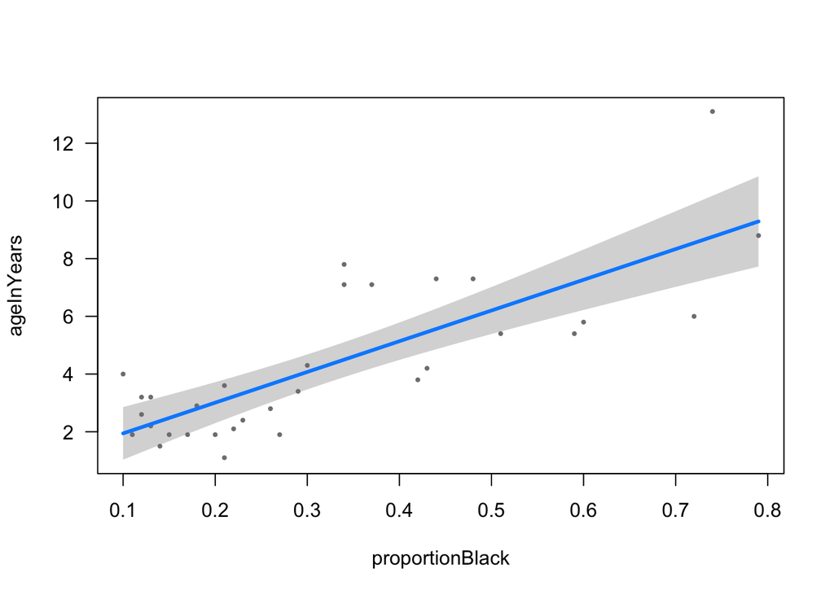

```r
library(visreg)
visreg(lm.L, "proportionBlack")
```

# Categorical Independent Variable

What if we have have a categorical independent variable? For example, assume we were interested in fitting a regression model to to the `flies` data with `treatment` as the only independent variable.

```r
flies = read.csv(url("http://whitlockschluter.zoology.ubc.ca/wp-content/data/chapter18/chap18q07flyLifeSpan.csv"))
summary(flies)
```

```
##   lifespanDays       treatment     fertility
##  Min.   : 2.00   high-cost:420   fertile:420
##  1st Qu.:22.00   low-cost :422   sterile:422
##  Median :27.00
##  Mean   :27.74
##  3rd Qu.:33.00
##  Max.   :56.00
```

```r
lm.A = lm(lifespanDays ~ treatment, data = flies)
summary(lm.A)
```

```
##
## Call:
## lm(formula = lifespanDays ~ treatment, data = flies)
##
## Residuals:
##      Min       1Q   Median       3Q      Max
## -29.2204  -4.2204   0.7619   4.7796  24.7796
##
## Coefficients:
##                   Estimate Std. Error t value Pr(>|t|)
## (Intercept)        24.2381     0.4057   59.75   <2e-16 ***
## treatmentlow-cost   6.9823     0.5730   12.19   <2e-16 ***
## ---
## Signif. codes:  0 '***' 0.001 '**' 0.01 '*' 0.05 '.' 0.1 ' ' 1
##
## Residual standard error: 8.313 on 840 degrees of freedom
## Multiple R-squared:  0.1502, Adjusted R-squared:  0.1492
## F-statistic: 148.5 on 1 and 840 DF,  p-value: < 2.2e-16
```

First, note the residual standard error and the adjusted R-squared. The former indicates that on average we shold expect prediction error of 8.313 when trying to predict lifespan using treatment as the only independent variable. The adjusted R-squared tell us that we can explain about 14.92% of the variation in lifespan with treatment as the independent variable.

Second, predicted lifespan for the low-cost group is `24.2381 + 6.9823 = 31.2204` and predicted lifespan for the other group – `high-cost` – is 24.2381. So the difference in lifespan is 6.9823; average lifespan is higher by 6.9823 days in the low-cost group.

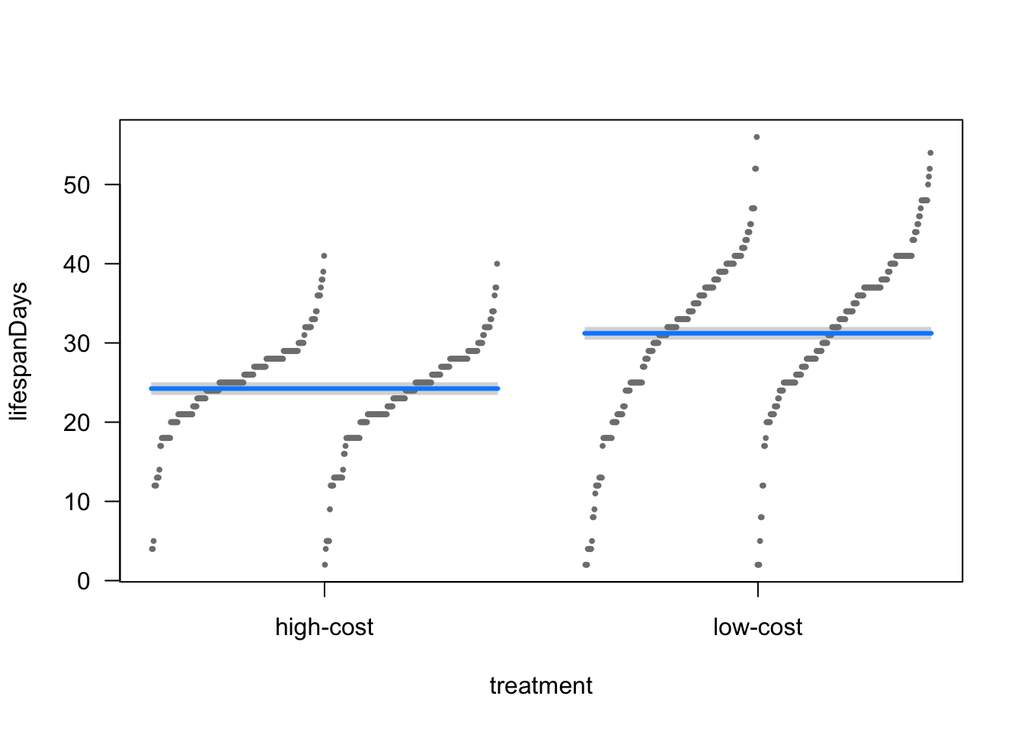

```r
library(visreg)
visreg(lm.A, "treatment")
```